# LSA methods comparison (Python)

Anton Antonov

2021-11-25

```r
quit
library(reticulate)
# reticulate::py_config()
source("../R/UtilityFunctions.R")
```

```python
reticulate::repl_python()
import sys
sys.version_info
```

```
sys.version_info(major=3, minor=10, micro=2, releaselevel='final', serial=0)
```

# Introduction

This notebook shows how to use Latent Semantic Analysis (LSA) for deriving “topics” of images.

```python
# "Standard" packages
import pandas
import numpy
import random
import io
import time

# SSparseMatrix, SMR, and LSA packages
from SSparseMatrix import *
from SparseMatrixRecommender import *
from LatentSemanticAnalyzer import LatentSemanticAnalyzer

# Plotting packages
import matplotlib
import matplotlib.pyplot as plt
from mpl_toolkits.axes_grid1 import ImageGrid

# Image processing package(s)
from PIL import Image, ImageOps

# Random mandalas packages
from RandomMandala import random_mandala, figure_to_image
```

## Mandala collection

```python
# A list to accumulate random mandala images
mandala_images = []

# Generation loop
random.seed(443)
tstart = time.time()
for i in range(512):

    # Generate one random mandala figure
    fig2 = random_mandala(n_rows=None,
                          n_columns=None,
                          radius=[8, 6, 3],
                          rotational_symmetry_order=6,
                          symmetric_seed=True,
                          connecting_function='bezier_fill',
                          face_color="0.",
                          alpha = 1.0)
    fig2.tight_layout()

    # Convert the figure into an image and add it to the list
    mandala_images = mandala_images + [figure_to_image(fig2)]

    # Close figure to save memory
    plt.close(fig2)

# Invert image colors
mandala_images1 = [ImageOps.invert(img) for img in mandala_images]

# Binarize images
mandala_images2 = [im.convert('1') for im in mandala_images1]

# Resize images
width, height = mandala_images2[0].size
print([width, height])
```

```
[640, 480]
```

```python
ratio = height / width
new_width = 200
mandala_images3 = [img.resize((new_width, round(new_width * ratio)), Image.ANTIALIAS) for img in mandala_images2]
print("Process time: " + str(time.time()-tstart))
```

```
Process time: 18.983693838119507
```

```python
mandala_arrays = [numpy.asarray(x, dtype="int32") for x in mandala_images3]
```

# Process random mandalas collection

```python
mandala_images3[11]
```

```
<PIL.Image.Image image mode=1 size=200x150 at 0x286A71CF0>
```

Convert each image into array and flatten that array:

```python
mandala_arrays = [numpy.asarray(x, dtype="int32") for x in mandala_images3]
len(mandala_arrays)
```

```
512
```

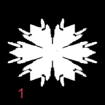

```r
quit
ParImageGrid(py$mandala_arrays[12], mfrow = c(1, 1))
```

Make a matrix of flattened mandalas:

```python
reticulate::repl_python()
mandalaMat = [x.reshape(x.shape[0] * x.shape[1]) for x in mandala_arrays]
mandalaMat = numpy.array(mandalaMat)
mandalaMat.shape
```

```
(512, 30000)
```

Make the corresponding `SSparseMatrix` object:

```python
mandalaSMat = SSparseMatrix(mandalaMat, row_names="", column_names="")
print(repr(mandalaSMat))
```

```
<512x30000 SSparseMatrix (sparse matrix with named rows and columns) of type '<class 'numpy.int32'>'
    with 3436475 stored elements in Compressed Sparse Row format, and fill-in 0.22372884114583333>
```

# LSA object creation

Assign the number of topics for the computations below:

```python
numberOfTopics = 40
```

Create the LSAMon object:

```python
start = time.time()
lsaObj = LatentSemanticAnalyzer().set_document_term_matrix(mandalaSMat).apply_term_weight_functions("None", "None", "None")
end = time.time()
print("\n\t\tCreation time : ", end-start)
```

```
        Creation time :  0.10448884963989258
```

The LSA object summary:

```python
print(repr(lsaObj))
```

```
<LatentSemanticAnalyzer object with document-term matrix dimensions 512x30000
    and with 0 extracted topics>
```

## SVD

Here we extract image topics using Singular Value Decomposition (SVD):

```python
tStart = time.time()

lsaSVDObj = lsaObj.extract_topics(number_of_topics=numberOfTopics, min_number_of_documents_per_term=0, method="SVD", max_steps=50)

tEnd = time.time()

print("Topic extraction time SVD : ", tEnd-tStart)
```

```
Topic extraction time SVD :  1.4983561038970947
```

Get the SVD topics matrix:

```python
svdH = lsaSVDObj.normalize_matrix_product(normalize_left=False).take_H().copy()
```

## NNMF

Here we extract image topics using Non-Negative Matrix Factorization (NNMF):

```python
tStart = time.time()

lsaNNMFObj = lsaObj.extract_topics(number_of_topics=numberOfTopics, min_number_of_documents_per_term=0, method="NNMF", max_steps=12)
```

Get the NNMF topics matrix:

```python
nnmfH = lsaNNMFObj.normalize_matrix_product(normalize_left=False).take_H().copy()
```

# Show topics interpretation

## SVD

Get the topics matrix from the LSA object and convert it into a dense array:

```python
svdTopicsArray = svdH.sparse_matrix().todense()
svdTopicsArray.shape
```

```
(40, 30000)
```

Show the interpretation of the extracted image topics:

```python
imageSizeX, imageSizeY = mandala_images3[0].size
svdTopicImages = [(svdTopicsArray[i,:]*255).reshape(imageSizeY, imageSizeX) for i in range(svdTopicsArray.shape[0])]
svdTopicImages2 = [Image.fromarray(x) for x in svdTopicImages]
```

```python
svdTopicImages2
```

```
[<PIL.Image.Image image mode=F size=200x150 at 0x283113880>, <PIL.Image.Image image mode=F size=200x150 at 0x283112920>, <PIL.Image.Image image mode=F size=200x150 at 0x283113AF0>, <PIL.Image.Image image mode=F size=200x150 at 0x283112170>, <PIL.Image.Image image mode=F size=200x150 at 0x283112FB0>,…
```

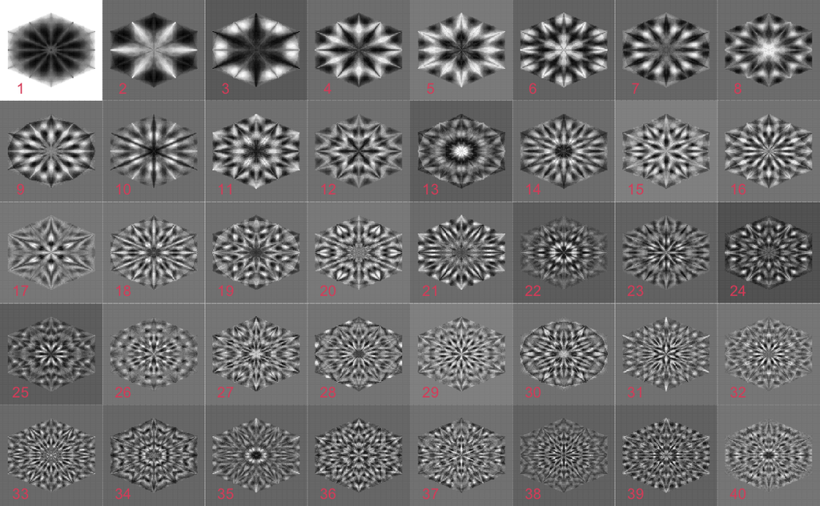

```r
quit
ParImageGrid(py$svdTopicImages, mfrow = c(5,8))
```

## NNMF

Get the topics matrix from the LSA object and convert it into a dense array:

```python
nnmfTopicsArray = nnmfH.sparse_matrix().todense()
nnmfTopicsArray.shape
```

```
(40, 30000)
```

Show the interpretation of the extracted image topics:

```python
imageSizeX, imageSizeY = mandala_images3[0].size
nnmfTopicImages = [(nnmfTopicsArray[i,:]*255).reshape(imageSizeY, imageSizeX) for i in range(nnmfTopicsArray.shape[0])]
nnmfTopicImages2 = [Image.fromarray(x) for x in nnmfTopicImages]
```

```python
nnmfTopicImages2
```

```
[<PIL.Image.Image image mode=F size=200x150 at 0x286A422F0>, <PIL.Image.Image image mode=F size=200x150 at 0x286A42D70>, <PIL.Image.Image image mode=F size=200x150 at 0x286A405B0>, <PIL.Image.Image image mode=F size=200x150 at 0x286A43E20>, <PIL.Image.Image image mode=F size=200x150 at 0x286A41330>,…
```

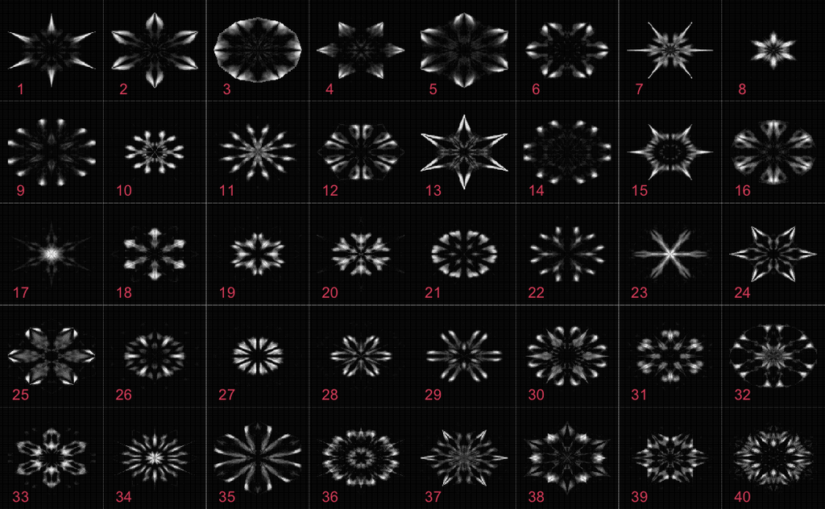

```r
ParImageGrid(py$nnmfTopicImages, mfrow = c(5,8))
```

# Approximation

```python
reticulate::repl_python()
random.seed(89)

# Consider using radius = [8, 6, 3]
fig = random_mandala(radius=[8, 6, 3],
                     rotational_symmetry_order=6,
                     symmetric_seed=True,
                     connecting_function='bezier_fill',
                     face_color="0.",
                     alpha = 1.0)

# Convert the mandala figure to image
testMandala = figure_to_image(fig)
testMandala
```

```
<PIL.Image.Image image mode=RGB size=640x480 at 0x286D53BE0>
```

```python
# Resize image
testMandala1 = testMandala.resize((new_width, round(new_width * ratio)), Image.ANTIALIAS)

# Invert image colors
testMandala2 = ImageOps.invert(testMandala)

# Binarize image
testMandala3 = testMandala2.convert('1')

# Resize image
testMandala4 = testMandala3.resize((new_width, round(new_width * ratio)), Image.ANTIALIAS)

# The image
testMandala4
```

```
<PIL.Image.Image image mode=1 size=200x150 at 0x286D0F640>
```

Get the corresponding vector:

```python
# Flatten array:
testMandalaArray = numpy.asarray(testMandala4, dtype="int32")
```

```r
quit
ParImageGrid(list(testMandalaArray), mfrow = c(1,1))
```

```
Error in ParImageGrid(list(testMandalaArray), mfrow = c(1, 1)) :
  object 'testMandalaArray' not found
```

Make a query matrix:

```python
testMandalaMat = testMandalaArray.reshape(1, testMandalaArray.shape[0] * testMandalaArray.shape[1])
testMandalaMat = numpy.array(testMandalaMat)
matQuery = SSparseMatrix(testMandalaMat, row_names="", column_names="")
print(repr(matQuery))
```

```
<1x30000 SSparseMatrix (sparse matrix with named rows and columns) of type '<class 'numpy.int32'>'
    with 5996 stored elements in Compressed Sparse Row format, and fill-in 0.19986666666666666>
```

## SVD

Represent by topics:

```python
resMat = lsaSVDObj.represent_by_topics(matQuery, method="recommendation").take_value()
resMat
```

```
<1x40 SSparseMatrix (sparse matrix with named rows and columns) of type '<class 'numpy.float64'>'
    with 40 stored elements in Compressed Sparse Column format, and fill-in 1.0>
```

```python
approx = resMat.dot(svdH)
approx2 = apply_term_weight_functions(approx, "None", "None", "AbsMax")
approx2.data
```

```
array([0.3356531 , 0.0007705 , 0.0132503 , ..., 0.00452334, 0.3357699 ,
       0.0141775 ])
```

```python
approxImg = (255 - approx2.todense().reshape(imageSizeY, imageSizeX)*255)
approxImg2 = Image.fromarray(approxImg)

fig = plt.figure(figsize=(5., 5.))
grid = ImageGrid(fig, 111,
                 nrows_ncols=(1,2),
                 axes_pad=0.02,
                 )

for ax, img in zip(grid, [approxImg2, testMandala1]):
    ax.imshow(img)
    ax.set(xticks=[], yticks=[])

figure_to_image(fig)
```

```
[[], []]
[[], []]
<PIL.Image.Image image mode=RGB size=500x500 at 0x3243D0B20>
```

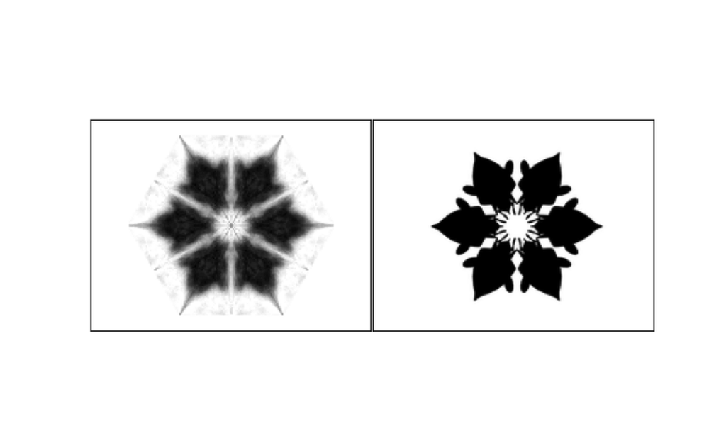

```python
plt.show()
```